**CSE2215** - Computer Graphics

Elmar Eisemann, Ricardo Marroqium, Mathijs Molenaar

# Shading

This assignment focuses on the concepts behind various shading models (which define the appearance of an object’s surface) and the placement of lights (to illuminate these objects). You will learn about concepts such as Lambertian, Phong and Blinn-Phong shading, and you will build your own cartoon-like shader.

In modern graphics pipelines, we would write shaders, which are small programs to define these shading models efficiently, and are often run on the GPU. Today, however, we will work in a simulated framework allowing us to write these shaders on the CPU. The functions you will implement are called for each vertex, and the resulting colour will be mapped on the model. There are many comments in the code to help you along, so read these carefully.

### Rules

For this assignment the following rules apply:

**General**

- The assignment must be done **individually**
- All code must be written by you. Any external help (e.g. working together, copying code) is considered fraud. Code that was made in a group work may not be reused.
- Sharing any code is not permitted and considered fraud.
- Your code **must compile on Windows with Visual Studio 2022**. We will not grade your code otherwise!

**Grading**

- Your code is graded by testing the functions you implement for various inputs. The number of points you receive is based on the percentage of correct cases.
- The grade is computed as $\text{grade} = 1 + \frac{\text{points}}{\text{max points}} * 9$
- You will receive a breakdown of your grade in the feedback section on Brightspace.

**Submission**

- You should submit your code on Brightspace,
- Hand in **only** `src/your_code_here.h` and do not change the name of this file.
- Any modifications made to files outside of `your_code_here.h` will not be considered. If modifications to other files are required for `your_code_here.h` to compile then your submission will not be graded.
- Do not modify the function signatures of any of the functions in `your_code_here.h`. This may break the testing script which means your code will not be graded.
- Late submissions must be submitted *as soon as possible* to the “Assignment 3 - Late Submissions” assignment on Brightspace.
  - The following penalty will be applied: $\text{adjusted grade} = \text{grade} - 1 - \lceil\frac{\text{minutes late}}{10}\rceil$

## Illumination models

Use the user interface (GUI) to place the currently selected light at the current camera position. Use the buttons to add or release light sources. You can select a light source by using the dropdown. Once selected you can change the colour of the light using a colour picker.

### 1. Value Table (no points)

Before you start implementing the different shading models we recommend that you first work out some examples by hand in a value table. Make sure that the results make sense to you. We provide a couple example scenarios but we highly recommend you to come up with some test cases on your own as well.

Use the value table as a reference to compare against when you start coding. You do not have to hand in the value table.

| Vertex | Light | Camera | Kd | Ks | Shininess | Light Colour | Result |
| --- | --- | --- | --- | --- | --- | --- | --- |
| (0,0,0) | (0,2,0) | (0,1,0) | (1,1,1) | (0,0,0) | 0 | (1,1,1) | … |
| (0,0,0) | (0,1,1) | (0,1,0) | (1,1,1) | (0,0,0) | 0 | (1,1,1) | … |
| (2,2,0) | (4,4,0) | (2,3,1) | (0.8,0.4,0.2) | (0.2,0.4,0.6) | 3 | (1,1,1) | … |
| … | … | … | … | … | … | … | … |

### 2. Lambertian Model (1 point)

First, we will define a simple diffuse surface shading. The basic formula for the Lambertian model is:
$$D = I K_d (N \cdot L)$$

Here $I$ is the light colour, $K_d$ is the diffuse colour, $N$ is the normal vector at the current point, and $L$ is the direction from vertex towards the light. Make sure that any light coming from behind the surface results in black $(0,0,0)$.

**Implement the Lambertian Model in the `diffuseOnly()` function in `src/your_code_here.h`**

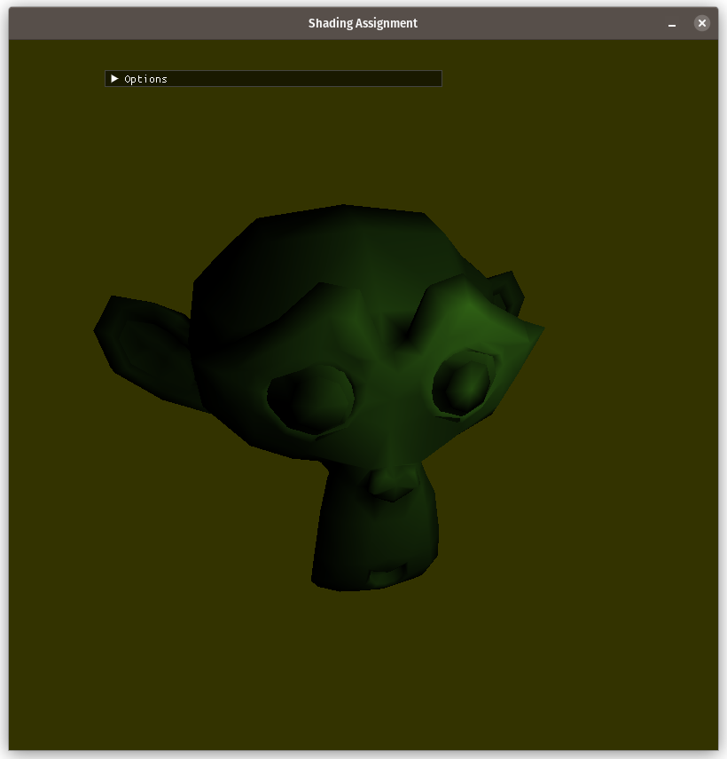

The Lambertian model

### 3. Phong Specular Model (1 point)

Second, we will implement the Phong specular model, which introduces view-dependent effects called specularities. The basic formula for the Phong model is:
$$S = I K_s (R \cdot V)^s$$

Here $I$ is the light colour, $K_s$ is the specular colour, $R$ is the reflection vector (light direction reflected away from the normal), $V$ is the view direction (towards the camera), and $s$ is the the shininess, influencing the size of the highlight. Be aware: as with the Lambert model a light placed behind the model should not illuminate it from the front!.

**Implement the Phong model in the `phongSpecularOnly()` function in `src/your_code_here.h`**

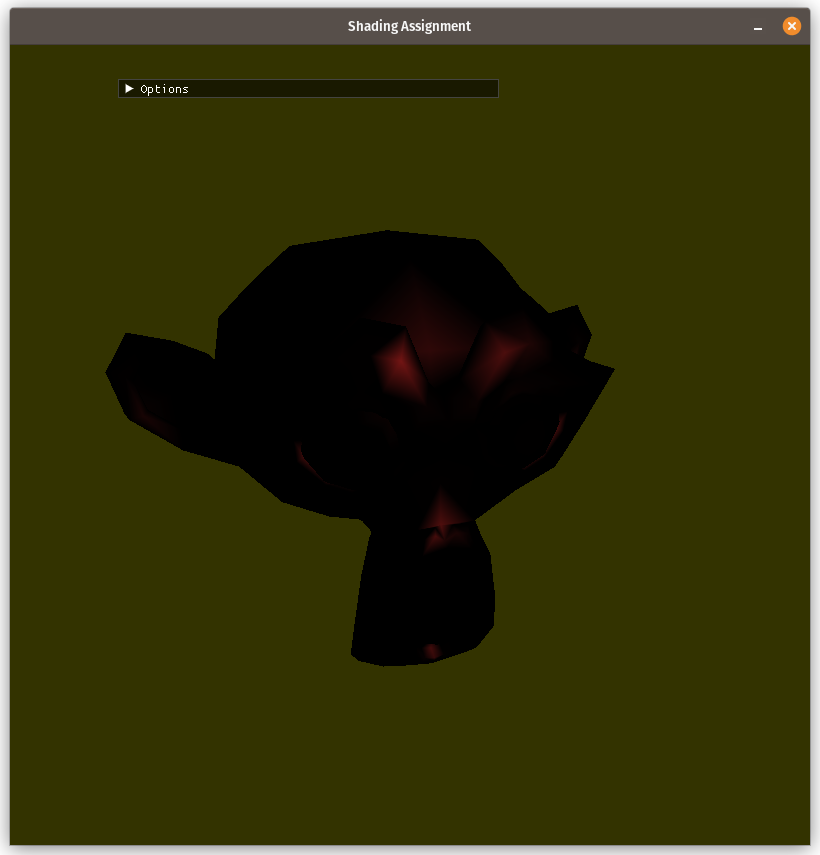

Specular only

[figure not shown]

Diffuse and specular combined

### 4. Blinn-Phong Specularity Model (1 point)

Third, we will implement the Blinn-Phong specularity model, which is similar to the Phong model above. The basic formula for the Blinn-Phong model is:
$$S = I K_s (H \cdot N)^s$$

The difference here lies in the use of $N$ (the normal) and $H$, which is a half vector: a *unit* vector which lies half way between the view direction $V$ and the light direction $L$. Again make sure that a light placed behind the model does not illuminate it from the front.

**Implement the Blinn-Phong model in the `blinnPhongSpecularOnly()` function in `src/your_code_here.h`**

[figure not shown]

Specular only

[figure not shown]

Diffuse and specular combined

### 5. Gooch Diffuse Shading (1 point)

Now, we will implement Gooch shading, which takes a more stylized approach to shading. Gooch builds on the idea that colour temperature has an effect on how humans perceive depth. Surfaces facing the sun typically appear warmer (yellow) than surfaces facing away from it, which will have a cooler (blue) colour temperature. We model this effect by using the angle between the normal and the light vector (Lambertian) to interpolate between warm and cool:
$$D = I ((\frac{1+N \cdot L}{2}) k_{warm} + (1-\frac{1+N \cdot L}{2}) k_{cool})$$

The quantity $N \cdot L$ varies over the interval $[-1,1]$ so a light behind the surface may still illuminate it. The terms $k_{cool}$ and $k_{warm}$ mix the surface colour $k_d$ mixed with a blue/yellow tint respectively:
$$\begin{aligned}
k_{cool} &= k_{blue} + \alpha k_d \\
k_{warm} &= k_{yellow} + \beta k_d
\end{aligned}$$

where $k_{blue} = (0,0,b)$ and $k_{yellow}=(y,y,0)$. $k_{cool}$ and $k_{warm}$ may fall outside the valid colour range of $[0, 1]$ which you may ignore. More information on the Gooch shading model can be found in the paper [A Non-Photorealistic Lighting Model For Automatic Technical Illustration by Gooch et al.](https://dl.acm.org/doi/pdf/10.1145/280814.280950). There is a mistake in one of their formulas, can you spot it?

**Implement the Gooch shading model in the `gooch()` function in `src/your_code_here.h`**

[figure not shown]

Gooch only

[figure not shown]

Gooch with Blinn-Phong specular

## And there was light!

Now, we will focus on control of the illumination. For an artist, it can be difficult to control the light positions (just look at the credits of any modern movie, there are hundreds of people working on light placements). Our goal is to simplify this work and provide the artist with a tool to efficiently place lights in an indirect manner. We will use the function `userInteraction()` in the following exercises. This function receives where the user has “clicked” (as the mouse button is used for the navigation, pressing space will launch this function instead of a click). This interaction will trigger a function `userInteraction...()`. We will use these functions to define a new light position, based on different criteria. To switch the interaction mode use the drop down near the bottom of the UI.

### 6. Placing the light with the mouse (1 point)

**Implement the function `userInteractionSphere()` in `src/your_code_here.h`.**

[figure not shown]

From the front, where the light was placed

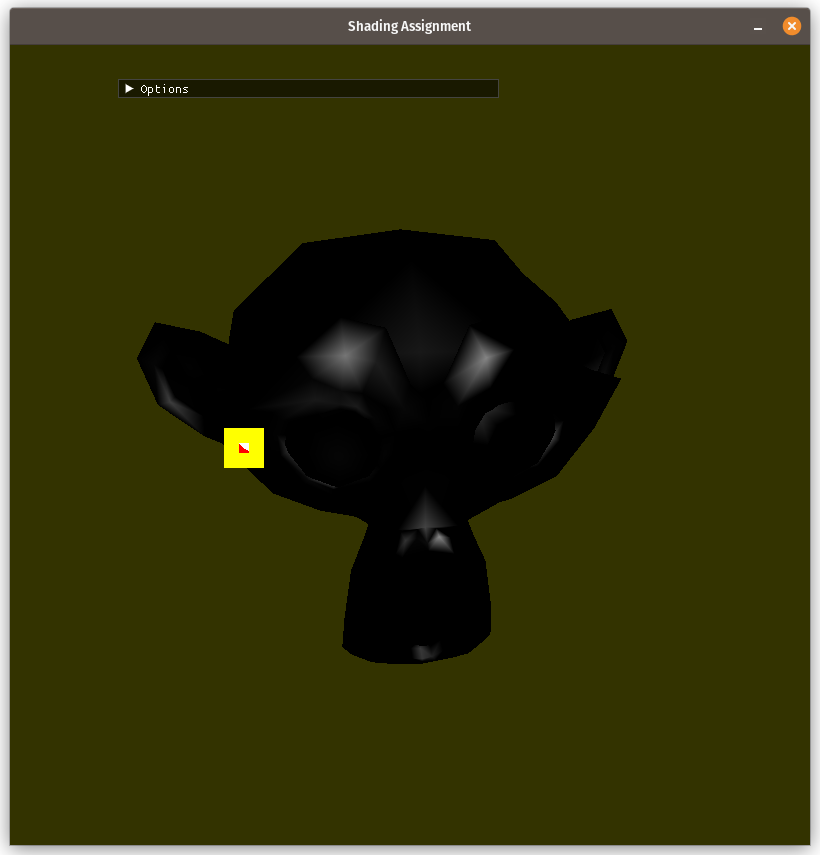

### 7. Placing the light according to shading (1 point)

This time, the new light position should be chosen such that the light produces exactly a lambertian shading of zero at the clicked location. There are several possibilities to achieve this goal! The implicit condition is that $L \cdot N$ should be exactly zero at the clicked position, which leaves some degrees of freedom.

**Implement the function `userInteractionShadow()` in `src/your_code_here.h`.**

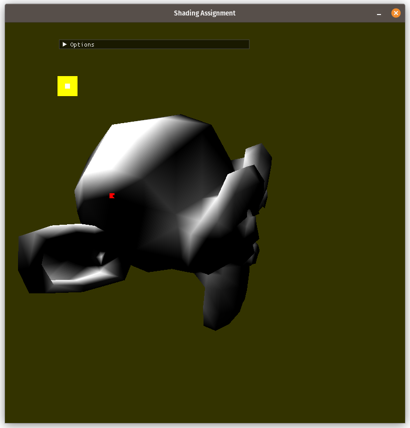

[figure not shown]

Placing the light according to shading

### 8. Placing the light based on specularities (1 point)

This time, the new light position should be chosen such that the specularity is located exactly at the clicked location when viewed from the current camera position. Remember, placing a specularity is not easy because its position depends on the view *AND* the light.

**Implement the function `userInteractionSpecular()` in `src/your_code_here.h`.**

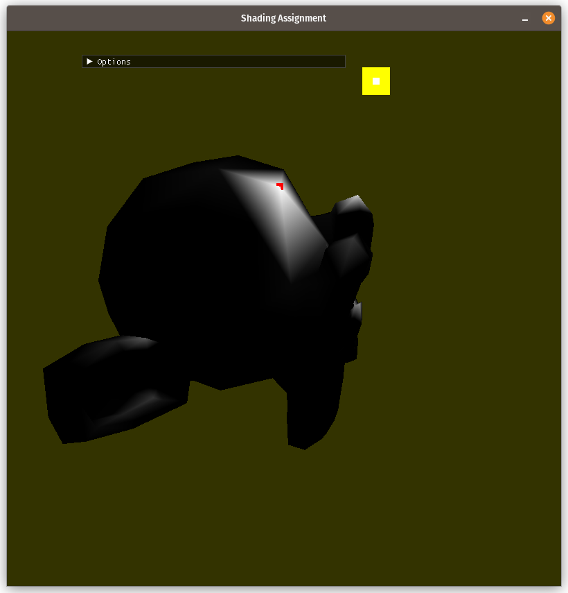

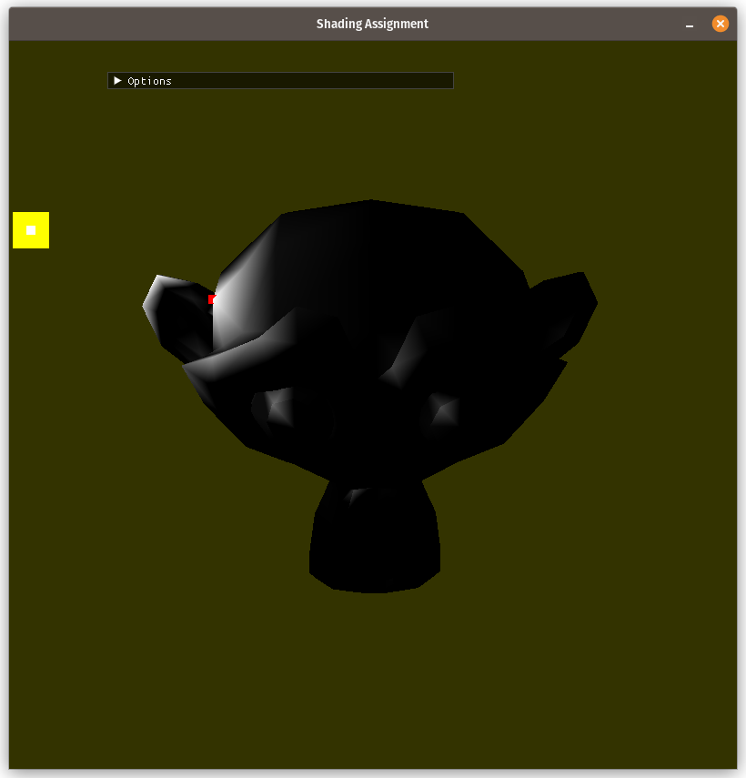

Placing the light based on specularities